# 0006_convnet_one_channel

Dan MacLean

2018-06-22

## A one channel convnet

Following on from the convent in `0005_convnet_explore` which uses inputs of 232,232,2 I’ll try the original 2, 232,1 data, see if that runs quicker. I think I may be thinking of these things as images too literally. So, loading in the scaled, 2,232,1 shaped data

```r
arab_data <- readRDS("../data/scaled_arab_TF.RDS")
new_order <- sample(1:8704)
shuffled_data <- list(
  x = arab_data$x[new_order,,],
  y = as.numeric(arab_data$y[new_order])
)

train_i <- 1:6900
val_i <- 6901:7802
test_i <- 7803:8704

x_train <- shuffled_data$x[train_i,,]
x_val <- shuffled_data$x[val_i,,]
x_test <- shuffled_data$x[test_i,,]

y_train <- shuffled_data$y[train_i]
y_val <- shuffled_data$y[val_i]
y_test <- shuffled_data$y[test_i]
```

Let’s use the rough convnet from the first section of `0005_convnet_explore`.

```r
model <- tryCatch({
  keras_model_sequential() %>%
    layer_conv_2d(filters = 32, kernel_size = c(2,5), activation = "relu", input_shape = c(2,232,1), padding = "same") %>%
    layer_max_pooling_2d(pool_size = c(2,2)) %>%
    layer_conv_2d(filters = 64, kernel_size = c(2,5), activation = "relu", padding = "same") %>%
    layer_max_pooling_2d(pool_size = c(2,2)) %>%
    layer_conv_2d(filters = 64, kernel_size = c(2,5), activation = "relu",  padding = "same") %>%
    layer_flatten() %>%
    layer_dense(units = 64, activation = "relu") %>%
    layer_dense(units = 1, activation = "sigmoid")
},
warning = function(w) {
  print(paste("Warning:", w))
},
error = function(e){
  print(paste("Error:", e))
}

)
```

```
## [1] "Error: Error in py_call_impl(callable, dots$args, dots$keywords): ValueError: Negative dimension size caused by subtracting 2 from 1 for 'max_pooling2d_2/MaxPool' (op: 'MaxPool') with input shapes: [?,1,116,64].\n\nDetailed traceback: \n  File \"/Users/macleand/.virtualenvs/r-tensorflow/lib/…
```

Looks like this error might be related to the number of layers and the max pooling. Let’s strip the model back and see

```r
model <- tryCatch({
  keras_model_sequential() %>%
  layer_conv_2d(filters = 32, kernel_size = c(2,5), activation = "relu", input_shape = c(2,232,1), padding = "same") %>%
  layer_max_pooling_2d(pool_size = c(2,2)) %>%
  layer_flatten() %>%
  layer_dense(units = 64, activation = "relu") %>%
  layer_dense(units = 1, activation = "sigmoid")
},
warning = function(w) {
  print(paste("Warning:", w))
},
error = function(e){
  print(paste("Error:", e))
}

)

summary(model)
```

```
## ___________________________________________________________________________
## Layer (type)                     Output Shape                  Param #
## ===========================================================================
## conv2d_3 (Conv2D)                (None, 2, 232, 32)            352
## ___________________________________________________________________________
## max_pooling2d_3 (MaxPooling2D)   (None, 1, 116, 32)            0
## ___________________________________________________________________________
## flatten_1 (Flatten)              (None, 3712)                  0
## ___________________________________________________________________________
## dense_1 (Dense)                  (None, 64)                    237632
## ___________________________________________________________________________
## dense_2 (Dense)                  (None, 1)                     65
## ===========================================================================
## Total params: 238,049
## Trainable params: 238,049
## Non-trainable params: 0
## ___________________________________________________________________________
```

Great, so this one builds. Let’s see how we can add more layers..

```r
model <- tryCatch({
  keras_model_sequential() %>%
  layer_conv_2d(filters = 32, kernel_size = c(2,5), activation = "relu", input_shape = c(2,232,1), padding = "same") %>%
  layer_max_pooling_2d(pool_size = c(2,2)) %>%
  layer_conv_2d(filters = 64, kernel_size = c(2,5), activation = "relu", padding = "same") %>%
  layer_flatten() %>%
  layer_dense(units = 64, activation = "relu") %>%
  layer_dense(units = 1, activation = "sigmoid")
},
warning = function(w) {
  print(paste("Warning:", w))
},
error = function(e){
  print(paste("Error:", e))
}

)
summary(model)
```

```
## ___________________________________________________________________________
## Layer (type)                     Output Shape                  Param #
## ===========================================================================
## conv2d_4 (Conv2D)                (None, 2, 232, 32)            352
## ___________________________________________________________________________
## max_pooling2d_4 (MaxPooling2D)   (None, 1, 116, 32)            0
## ___________________________________________________________________________
## conv2d_5 (Conv2D)                (None, 1, 116, 64)            20544
## ___________________________________________________________________________
## flatten_2 (Flatten)              (None, 7424)                  0
## ___________________________________________________________________________
## dense_3 (Dense)                  (None, 64)                    475200
## ___________________________________________________________________________
## dense_4 (Dense)                  (None, 1)                     65
## ===========================================================================
## Total params: 496,161
## Trainable params: 496,161
## Non-trainable params: 0
## ___________________________________________________________________________
```

Right, so this is the biggest model I can seem to get without breaking. Let’s give it a whirl.

```r
tryCatch({
  model %>% compile(
    optimizer = "rmsprop",
    loss = "binary_crossentropy",
    metrics = c("accuracy")
  )

  history <- model %>% fit(
    x_train,
    y_train,
    epochs = 20,
    batch_size = 512,
    validation_data = list(x_val, y_val)
  )

plot(history)
},
error = function(e){
  print(paste("error: ", e))
}
)
```

```
## [1] "error:  Error in py_call_impl(callable, dots$args, dots$keywords): ValueError: Error when checking input: expected conv2d_4_input to have 4 dimensions, but got array with shape (6900, 2, 232)\n\nDetailed traceback: \n  File \"/Users/macleand/.virtualenvs/r-tensorflow/lib/python2.7/site-packa…
```

Model dies!

Looks like the input isn’t as expected, it looks like it wants a 4D tensor for an image. Not, my2D ones. I’ll rework it, manually in the build script, it can be built using

```bash
rake data/scaled_arab_TF_one_channel.RDS
```

Let’s load this new data and try it.

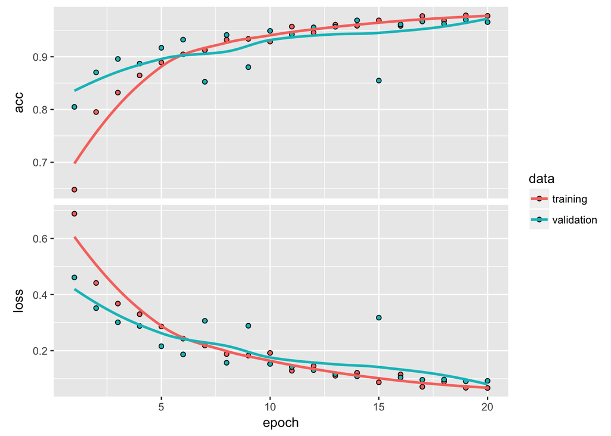

```r
arab_data <- readRDS("../data/scaled_arab_TF_one_channel.RDS")
new_order <- sample(1:8704)

shuffled_data <- list(
  x = arab_data$x[new_order,,,, drop = F],
  y = as.numeric(arab_data$y[new_order])
)


train_i <- 1:6900
val_i <- 6901:7802
test_i <- 7803:8704

x_train <- shuffled_data$x[train_i,,, ,drop = F]
x_val <- shuffled_data$x[val_i,,, ,drop = F]
x_test <- shuffled_data$x[test_i,,, ,drop = F]

y_train <- shuffled_data$y[train_i]
y_val <- shuffled_data$y[val_i]
y_test <- shuffled_data$y[test_i]

tryCatch({
  model %>% compile(
    optimizer = "rmsprop",
    loss = "binary_crossentropy",
    metrics = c("accuracy")
  )

  history <- model %>% fit(
    x_train,
    y_train,
    epochs = 20,
    batch_size = 512,
    validation_data = list(x_val, y_val)
  )

plot(history)
},
error = function(e){
  print(paste("error: ", e))
}
)
```